# Life Table estimate:Simulation and Real Dataset Study

BIOSTATISTICS 1 PROJECT REPORT

Parna Dutta, Sampriti Dey, Sukanya Pal

2025-12-16

## Introduction

The *Life Table* method estimates survival by dividing follow-up time into intervals and computing survival probabilities using the number at risk, events, and censored observations. Because censoring times are not exact, it relies on assumptions—typically that censored individuals withdraw uniformly within each interval. These assumptions and the grouping of event times introduce approximation error and potential bias, especially when intervals are wide or censoring is uneven. In contrast, the *Kaplan–Meier estimator* uses exact event and censoring times, avoids interval grouping, and therefore provides a more accurate and unbiased survival estimate. For this reason, Kaplan–Meier is preferred whenever precise event times are available, while the Life Table method is mainly used for grouped or older datasets.

## Methodology

In the empirical part of the project, the *kidney* dataset from the “KMsurv” package will be used. This dataset contains 119 observations on kidney infection recurrence times, event indicators, and treatment types. Survival times will be grouped into intervals, and life tables will be constructed. Kaplan–Meier estimates will also be computed for comparison. Graphical and numerical summaries will be used to study the differences between the methods.

### Loading Packages

```r
library(tidyverse)
library(survival)
library(KMsurv)
library(dplyr)
```

## 1. Simulation Study

### 1.1 Life-Table Builder Function

```r
build_life_table <- function(df, breaks) {
df <- df %>% mutate(interval = cut(time, breaks = breaks, right = TRUE, include.lowest = TRUE))
lt <- df %>%
group_by(interval) %>%
summarise(
d_j = sum(status == 1 , na.rm = TRUE),
w_j = sum(status == 0 , na.rm = TRUE),
inside = n()
) %>% ungroup()

n_j <- numeric(nrow(lt))
n_j[1] <- nrow(df)
if(nrow(lt) >= 2) {
for(j in 2:nrow(lt)) {
n_j[j] <- n_j[j-1] - lt$d_j[j-1] - lt$w_j[j-1]
}
}

lt <- lt %>% mutate(
n_j = n_j,
denom_uniform = n_j - w_j/2,
q_uniform = ifelse(denom_uniform > 0, d_j / denom_uniform, NA),
q_early   = ifelse((n_j - w_j) > 0, d_j / (n_j - w_j), NA),
q_late    = ifelse(n_j > 0, d_j / n_j, NA)
)

lt <- lt %>% mutate(
S_uniform = cumprod(1 - replace_na(q_uniform, 0)),
S_early   = cumprod(1 - replace_na(q_early, 0)),
S_late    = cumprod(1 - replace_na(q_late, 0))
)

interval_ends <- as.numeric(gsub("\\((.+),(.+)\\]", "\\2", lt$interval))
lt <- lt %>% mutate(time = interval_ends)
return(lt)
}
```

### 1.2 Simulation of Survival Data

```r
set.seed(2025)
n <- 1000
lambdaT <- 0.1
lambdaC <- 0.05

T <- rexp(n, rate = lambdaT)
C <- rexp(n, rate = lambdaC)

time <- pmin(T, C)
status <- as.integer(T <= C)

s_df <- data.frame(time, status)
```

```r
head(s_df)
```

```
##          time status
## 1  4.65240310      1
## 2 10.38634094      1
## 3  5.60569047      1
## 4  0.08504318      1
## 5  0.88620726      1
## 6  1.39062109      1
```

### 1.3 Life Table (Simulated Data)

```r
breaks <- seq(0, max(s_df$time) + 2, by = 2)
lt_sim <- build_life_table(s_df, breaks)
lt_sim
```

```
## # A tibble: 21 × 13
##    interval   d_j   w_j inside   n_j denom_uniform q_uniform q_early q_late
##    <fct>    <int> <int>  <int> <dbl>         <dbl>     <dbl>   <dbl>  <dbl>
##  1 [0,2]      178    84    262  1000         958       0.186   0.194  0.178
##  2 (2,4]      117    60    177   738         708       0.165   0.173  0.159
##  3 (4,6]      103    41    144   561         540.      0.191   0.198  0.184
##  4 (6,8]       67    36    103   417         399       0.168   0.176  0.161
##  5 (8,10]      54    29     83   314         300.      0.180   0.189  0.172
##  6 (10,12]     40    20     60   231         221       0.181   0.190  0.173
##  7 (12,14]     20    13     33   171         164.      0.122   0.127  0.117
##  8 (14,16]     29    11     40   138         132.      0.219   0.228  0.210
##  9 (16,18]     18     8     26    98          94       0.191   0.2    0.184
## 10 (18,20]     13     7     20    72          68.5     0.190   0.2    0.181
## # ℹ 11 more rows
## # ℹ 4 more variables: S_uniform <dbl>, S_early <dbl>, S_late <dbl>, time <dbl>
```

### 1.4 True Survival vs Life Table Plot

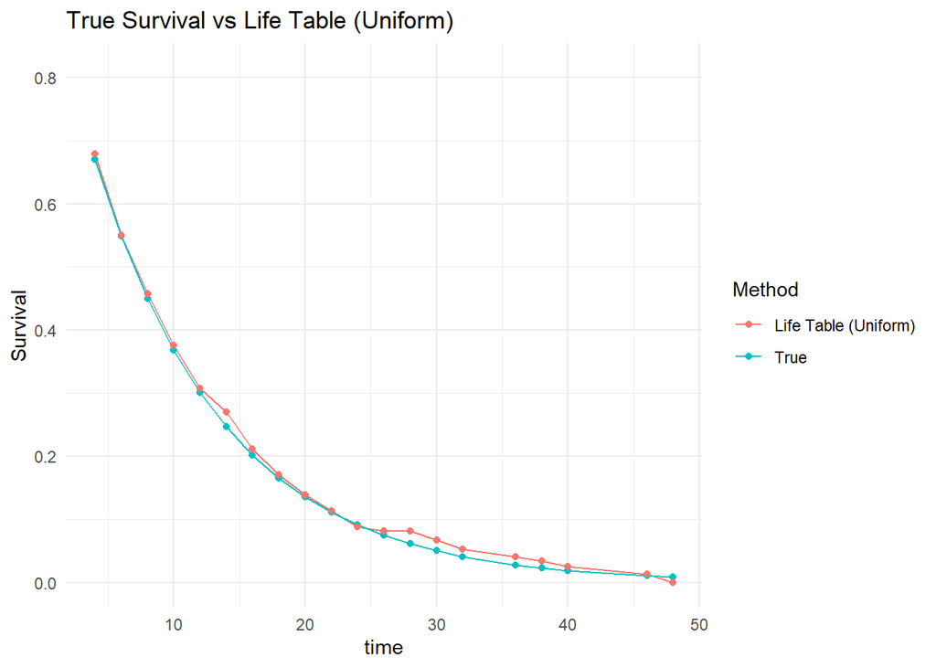

```r
interval_ends <- lt_sim$time
S_true <- exp(-(lambdaT * interval_ends))

plot_df <- data.frame(
time = rep(interval_ends, 2),
Survival = c(S_true, lt_sim$S_uniform),
Method = rep(c("True", "Life Table (Uniform)"), each = length(interval_ends))
)

ggplot(plot_df, aes(x = time, y = Survival, color = Method)) +
geom_line() +
geom_point() +
theme_minimal() +
labs(title = "True Survival vs Life Table (Uniform)")
```

```r
C_u<-runif(n,min=0,max=70)
# observed time
time_u <- pmin(T, C_u)

# event indicator: 1 = event occurred, 0 = censored
status_u <- as.integer(T <= C_u)
df_u<-data.frame(time_u, status_u)


#break time-points into intervals
df_u$interval<-cut(df_u$time_u,breaks=seq(0,max(df_u$time_u)+2,by=2),right=TRUE)
breaks_u=seq(0,max(df_u$time_u)+2,by=2)
lt_sim_u <- build_life_table(df_u, breaks_u)

# True Survival vs Life Table
interval_ends <- as.numeric(gsub("\\((.+),(.+)\\]", "\\2", lt_sim_u$interval));interval_ends
```

```
##  [1] NA  4  6  8 10 12 14 16 18 20 22 24 26 28 30 32 36 38 40 46 48
```

```r
S_uniform_u<-lt_sim$S_uniform;S_uniform_u
```

```
##  [1] 0.81419624 0.67964686 0.55013044 0.45775265 0.37521962 0.30730656
##  [7] 0.26994406 0.21086197 0.17048414 0.13812949 0.11326618 0.08809592
## [13] 0.08075459 0.08075459 0.06691095 0.05204185 0.04047699 0.03373083
## [19] 0.02529812 0.01264906 0.00000000
```

[figure not shown]

```r
S_true <- exp(-(lambdaT) * interval_ends)



plot_df_u <- data.frame(
  time = rep(interval_ends, 2),
  Survival = c(S_true, S_uniform_u),
  Method = rep(c("True Survival", "Life Table under Unifrom Censoring"),
               each = length(interval_ends))
)


ggplot(plot_df_u, aes(x = time, y = Survival, color = Method)) +
  geom_line(size = 0.7) +
  geom_point() +
  theme_minimal() +
  labs(title = "Simulated data:True Survival vs Life Table (Uniform Censored)",
       x = "Time", y = "Survival Probability")
```

### 1.5 Comparison of All Life-Table Assumptions

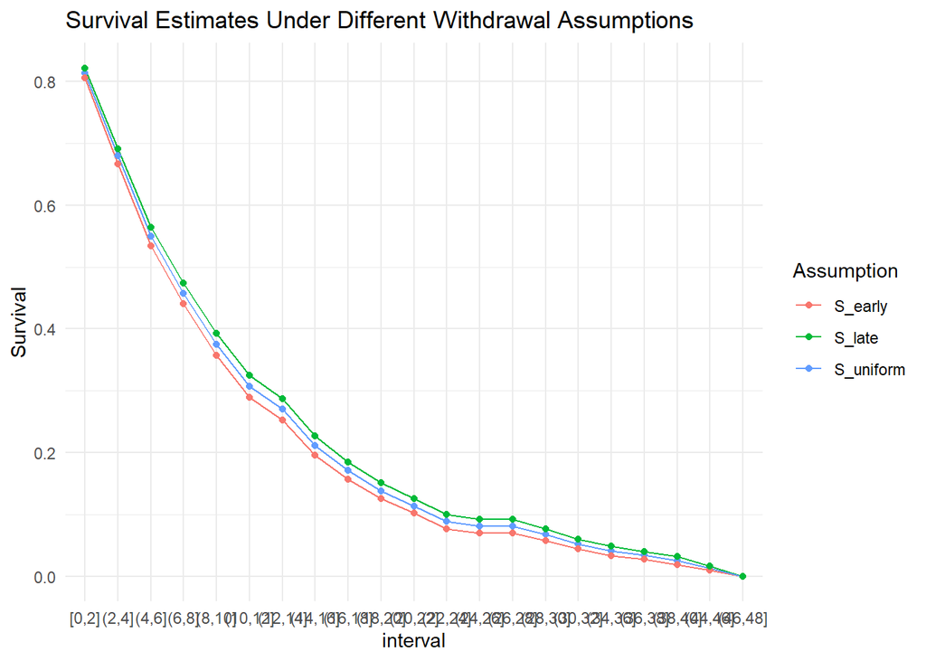

```r
life_tab_long_sim <- lt_sim %>%
select(interval, S_uniform, S_early, S_late) %>%
pivot_longer(cols = c(S_uniform, S_early, S_late),
names_to = "Assumption",
values_to = "Survival")

ggplot(life_tab_long_sim, aes(x = interval, y = Survival, color = Assumption, group = Assumption)) +
geom_line() +
geom_point() +
theme_minimal() +
labs(title = "Survival Estimates Under Different Withdrawal Assumptions")
```

**Findings:** All three curves (early, late, uniform withdrawal) show a steady decline in survival probability as the interval increases, indicating increasing event occurrence over time.The late-withdrawal assumption gives the highest survival estimates, as it assumes individuals remain at risk for longer.The early-withdrawal assumption gives the lowest survival estimates, because individuals are assumed to leave earlier, reducing the number at risk.The uniform-withdrawal assumption lies between early and late, giving moderate survival probabilities.

**Interpretation:** All curves converge towards near-zero survival in the final intervals, suggesting most simulated subjects experience the event by the end of follow-up. Differences among the three assumptions are small, especially in late intervals, indicating that the choice of assumption has a limited impact on long-term survival estimates.

### 1.6 KM Estimator (Simulated Data)

```r
km_fit <- survfit(Surv(time, status) ~ 1, data = s_df)
km_summary <- summary(km_fit, times = breaks[-1])

km_df <- data.frame(
time = km_summary$time,
KM_survival = km_summary$surv
)
```

```r
head(km_df)
```

```
##   time KM_survival
## 1    2   0.8124834
## 2    4   0.6784807
## 3    6   0.5489959
## 4    8   0.4567435
## 5   10   0.3741118
## 6   12   0.3061978
```

### 1.7 KM vs Life-Table Comparison

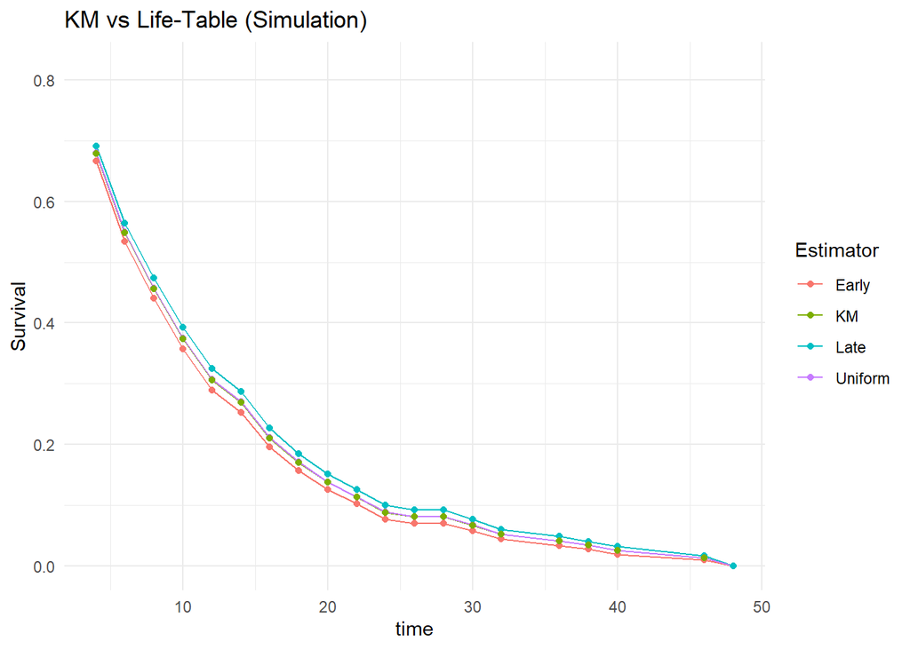

```r
act_df <- data.frame(
time = interval_ends,
Uniform = lt_sim$S_uniform,
Early   = lt_sim$S_early,
Late    = lt_sim$S_late
)

compare_all <- left_join(act_df, km_df, by="time") %>%
rename(KM = KM_survival)

compare_all_long <- compare_all %>%
pivot_longer(cols = c(Uniform, Early, Late, KM),
names_to = "Estimator",
values_to = "Survival")

ggplot(compare_all_long, aes(x = time, y = Survival, color = Estimator)) +
geom_line() +
geom_point() +
theme_minimal() +
labs(title = "KM vs Life-Table (Simulation)")
```

**Findings:** At early times (0–10) all curves start at the same point and decline similarly. The KM estimate lies between the life-table estimates. Early-withdrawal assumption gives slightly lower survival, while late-withdrawal gives slightly higher survival. Around mid-times (10–25) small separation becomes visible. Uniform and KM lie in between and closely match each other. At later times (25–40) all four curves continue to decline smoothly. Differences between estimators narrow as the number of surviving individuals decreases. At the tail (40+) all methods converge to nearly the same survival probability, approaching zero due to very few subjects remaining at risk.

**Interpretation:** KM curve serves as a reference and stays close to the uniform-withdrawal life-table estimate. Early and late withdrawal assumptions respectively underestimate and overestimate survival but only slightly.

## 1.8 Comparison of Life-Table Estimates with Exact Censoring (Simulated Average Survival):

In this section, we use simulated datasets to calculate the averaged life-table survival estimates across multiple simulation runs, considering the exact censoring times.These averaged estimates are then compared with the life-table estimates under the three withdrawal-time assumptions : early, uniform, and late, as well as with the Kaplan–Meier (KM) estimate.This comparison allows us to evaluate how closely the averaged life-table estimates align with the different withdrawal assumptions and with the KM curve, providing insight into the effect of the withdrawal assumption and the reliability of life-table estimates under exact censoring.

```r
n_sim<-100
breaks_n<-seq(0,48,by=2)
K <- length(breaks_n) - 1
time <- pmin(T, C)

life_table_once <- function(n, lambdaT, lambdaC, breaks_n) {

  # simulate times
  T <- rexp(n, rate = lambdaT)
  C <- rexp(n, rate = lambdaC)
  time <- pmin(T, C)

  K <- length(breaks_n) - 1

  n_j <- numeric(K)
  d_j <- numeric(K)
  w_j <- numeric(K)
  q_j <- numeric(K)

  n_j[1] <- n

  for (j in 1:K) {

    in_interval <- (time > breaks_n[j] & time <= breaks_n[j + 1])

    d_j[j] <- sum(in_interval & (T <= C))
    w_j[j] <- sum(in_interval & (C < T))

    q_j[j] <- d_j[j] / n_j[j]

    if (j < K) {
      n_j[j + 1] <- n_j[j] - d_j[j] - w_j[j]
    }
  }

  S_j <- cumprod(1 - q_j)

  return(list(d = d_j, w = w_j, q = q_j, S = S_j))
}

n_j <- numeric(K)
d_j <- numeric(K)
w_j <- numeric(K)
q_j <- numeric(K)

n_j[1] <- n

for (j in 1:K) {

  in_interval <- (time > breaks_n[j] & time <= breaks_n[j + 1])

  # deaths
  d_j[j] <- sum(in_interval & (T <= C))

  # censorings
  w_j[j] <- sum(in_interval & (C < T))

  # failure probability (as you want)
  q_j[j] <- d_j[j] / n_j[j]

  # update risk set
  if (j < K) {
    n_j[j + 1] <- n_j[j] - d_j[j] - w_j[j]
  }
}

# storage matrices
d_mat <- matrix(0, nrow = n_sim, ncol = K)
w_mat <- matrix(0, nrow = n_sim, ncol = K)
q_mat <- matrix(0, nrow = n_sim, ncol = K)
S_mat <- matrix(0, nrow = n_sim, ncol = K)

for (s in 1:n_sim) {
  lt <- life_table_once(n, lambdaT, lambdaC, breaks_n)
  d_mat[s, ] <- lt$d
  w_mat[s, ] <- lt$w
  q_mat[s, ] <- lt$q
  S_mat[s, ] <- lt$S
}

d_avg <- colMeans(d_mat)
w_avg <- colMeans(w_mat)
q_avg <- colMeans(q_mat)
S_avg <- colMeans(S_mat)

avg_life_table <- data.frame(
  interval = paste0("(", breaks_n[-length(breaks_n)], ", ", breaks_n[-1], "]"),
  d_avg = d_avg,
  w_avg = w_avg,
  q_avg = q_avg,
  S_avg = S_avg
)

print(avg_life_table)
```

```
##    interval  d_avg w_avg     q_avg      S_avg
## 1    (0, 2] 175.21 85.98 0.1752100 0.82479000
## 2    (2, 4] 128.23 63.86 0.1735789 0.68163458
## 3    (4, 6]  93.13 47.51 0.1703131 0.56555586
## 4    (6, 8]  70.08 35.07 0.1726290 0.46791361
## 5   (8, 10]  50.65 25.71 0.1683733 0.38914415
## 6  (10, 12]  39.70 19.29 0.1766640 0.32038531
## 7  (12, 14]  28.84 13.59 0.1744566 0.26453495
## 8  (14, 16]  20.90 10.57 0.1697086 0.21958764
## 9  (16, 18]  15.18  8.00 0.1649323 0.18324140
## 10 (18, 20]  11.85  6.23 0.1722698 0.15157551
## 11 (20, 22]   8.55  4.33 0.1695102 0.12588709
## 12 (22, 24]   6.29  3.22 0.1685096 0.10467645
## 13 (24, 26]   4.75  2.23 0.1706135 0.08687158
## 14 (26, 28]   3.64  1.68 0.1717286 0.07197050
## 15 (28, 30]   2.76  1.24 0.1699221 0.05951643
## 16 (30, 32]   2.16  0.86 0.1804437 0.04889362
## 17 (32, 34]   1.56  0.74 0.1760796 0.04008913
## 18 (34, 36]   1.24  0.50 0.2083193 0.03215244
## 19 (36, 38]   0.77  0.40       NaN        NaN
## 20 (38, 40]   0.56  0.29       NaN        NaN
## 21 (40, 42]   0.50  0.21       NaN        NaN
## 22 (42, 44]   0.35  0.14       NaN        NaN
## 23 (44, 46]   0.22  0.10       NaN        NaN
## 24 (46, 48]   0.21  0.03       NaN        NaN
```

```r
interval_ends_n <- as.numeric(gsub("\\((.+),(.+)\\]", "\\2",
avg_life_table$interval))

km_df_n <- data.frame(
  time = km_summary$time[1:20],
  KM_survival = km_summary$surv[1:20]
)

act_df_n <- data.frame(
  time = interval_ends_n[1:20],
  S_uniform = lt_sim$S_uniform[1:20],
  S_early   = lt_sim$S_early[1:20],
  S_late    = lt_sim$S_late[1:20],
  S_avg     = avg_life_table$S_avg[1:20]
)

compare_all_n <- left_join(act_df_n, km_df_n, by = "time")
head(compare_all_n)
```

```
##   time S_uniform   S_early    S_late     S_avg KM_survival
## 1    2 0.8141962 0.8056769 0.8220000 0.8247900   0.8124834
## 2    4 0.6796469 0.6666441 0.6916829 0.6816346   0.6784807
## 3    6 0.5501304 0.5345973 0.5646894 0.5655559   0.5489959
## 4    8 0.4577526 0.4405868 0.4739600 0.4679136   0.4567435
## 5   10 0.3752196 0.3571072 0.3924509 0.3891442   0.3741118
## 6   12 0.3073066 0.2894091 0.3244941 0.3203853   0.3061978
```

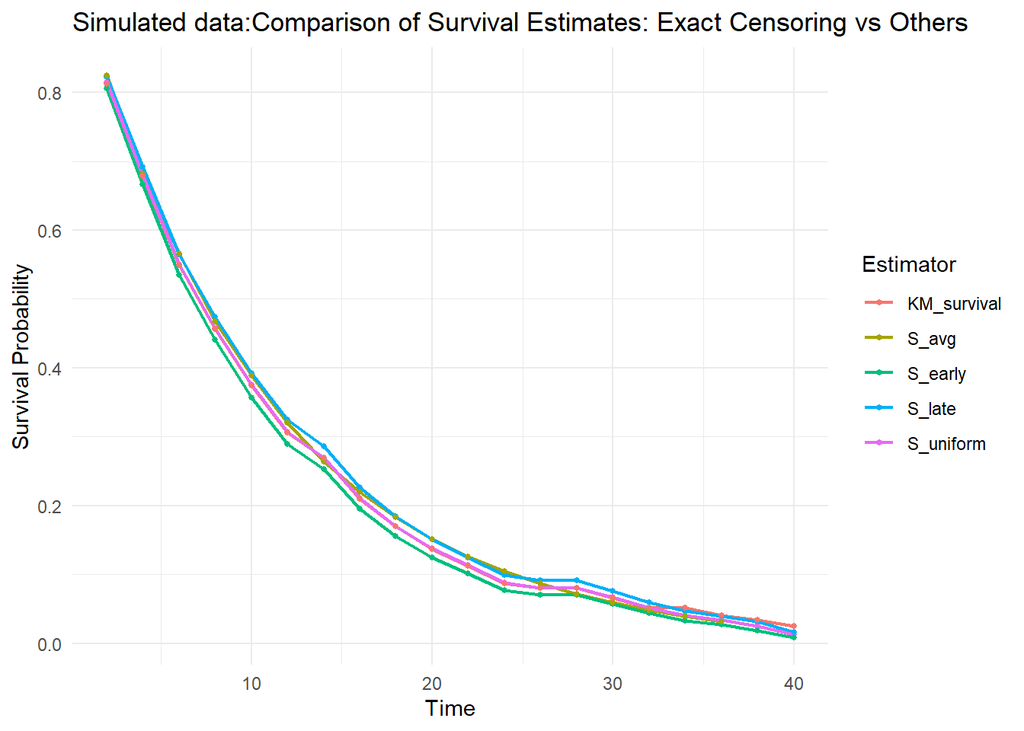

```r
compare_all_long_n <- compare_all_n %>%
  pivot_longer(cols = c(S_uniform,S_early,S_late,S_avg ,KM_survival),
               names_to = "Estimator",
               values_to = "Survival")

ggplot(compare_all_long_n, aes(x = time, y = Survival, color = Estimator)) +
  geom_line(size = 0.8) +
  geom_point(size = 1) +
  theme_minimal() +
  labs(
    title = "Simulated data:Comparison of Survival Estimates: Exact Censoring vs Others",
    x = "Time",
    y = "Survival Probability"
  )
```

**Interpretation:** Life-table survival estimates are sensitive to assumptions about when censoring happens within intervals. In simulations with exact censoring times, the Kaplan–Meier estimator gives the most accurate survival estimates because it does not rely on interval grouping or withdrawal-time assumptions.Averaging life-table estimates over repeated simulations reduces random variability but cannot remove the structural bias from using interval-based methods. The differences between life-table and Kaplan–Meier estimates are therefore due to the method itself, not random variation in the simulations.

Overall, this study confirms that classical life-table estimators behave as expected under censoring and highlights the advantage of using exact censoring information when it is available.

## 2. Real Dataset Study

The kidney dataset is a real-life clinical trial dataset that records catheter failure times for patients undergoing kidney treatment. It contains four key variables:

1. time – Number of days until catheter failure or censoring.
2. delta – Event indicator:

   ```
    1 = catheter failure occurred

    0 = observation is censored
   ```

3. type – Catheter insertion method:

   ```
    1 = surgically inserted catheter

    2 = percutaneous catheter
   ```

4. id – Patient identifier, used to track repeated catheter insertions for the same patient.

### 2.1 Kidney Dataset Life Table

```r
build_life_table_k <- function(df, breaks) {
df <- df %>% mutate(interval = cut(time, breaks = breaks, right = TRUE, include.lowest = TRUE))
lt <- df %>%
group_by(interval) %>%
summarise(
d_j_k = sum(delta == 1),
w_j_k = sum(delta == 0),
inside = n()
) %>% ungroup()

n_j_k <- numeric(nrow(lt))
n_j_k[1] <- nrow(df)
for(j in 2:nrow(lt)) {
n_j_k[j] <- n_j_k[j-1] - lt$d_j_k[j-1] - lt$w_j_k[j-1]
}

lt <- lt %>% mutate(
n_j_k = n_j_k,
q_uniform_k = d_j_k / (n_j_k - w_j_k/2),
q_early_k = d_j_k / (n_j_k - w_j_k),
q_late_k = d_j_k / n_j_k
)

lt <- lt %>% mutate(
S_uniform_k = cumprod(1 - replace_na(q_uniform_k, 0)),
S_early_k   = cumprod(1 - replace_na(q_early_k, 0)),
S_late_k    = cumprod(1 - replace_na(q_late_k, 0))
)

interval_ends <- as.numeric(gsub("\\((.+),(.+)\\]", "\\2", lt$interval))
lt$time <- interval_ends

return(lt)
}

data(kidney)
breaks_k <- seq(0, max(kidney$time) + 2, by = 2)
lt_k <- build_life_table_k(kidney, breaks_k)
```

```r
head(lt_k)
```

```
## # A tibble: 6 × 12
##   interval d_j_k w_j_k inside n_j_k q_uniform_k q_early_k q_late_k S_uniform_k
##   <fct>    <int> <int>  <int> <dbl>       <dbl>     <dbl>    <dbl>       <dbl>
## 1 [0,2]        7    14     21   119      0.0625    0.0667   0.0588       0.938
## 2 (2,4]        4    15     19    98      0.0442    0.0482   0.0408       0.896
## 3 (4,6]        3    10     13    79      0.0405    0.0435   0.0380       0.860
## 4 (6,8]        1    10     11    66      0.0164    0.0179   0.0152       0.846
## 5 (8,10]       3     7     10    55      0.0583    0.0625   0.0545       0.796
## 6 (10,12]      2     7      9    45      0.0482    0.0526   0.0444       0.758
## # ℹ 3 more variables: S_early_k <dbl>, S_late_k <dbl>, time <dbl>
```

### 2.2 Life Table Plots (Kidney)

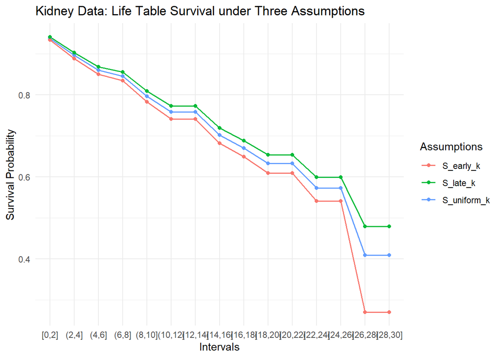

```r
life_tab_long_kidney <- lt_k %>%
select(interval, S_uniform_k, S_early_k, S_late_k) %>%
pivot_longer(cols = c(S_uniform_k, S_early_k, S_late_k),
names_to = "Assumptions",
values_to = "Survival")

ggplot(life_tab_long_kidney, aes(x = interval, y = Survival, color = Assumptions,group=Assumptions)) +
geom_line(size = 0.6) +
geom_point() +
theme_minimal() +
labs(
title = "Kidney Data: Life Table Survival under Three Assumptions",
x = "Intervals", y = "Survival Probability"
)
```

**Interpretation:** In the kidney dataset, the life-table survival estimates behave as expected under different withdrawal assumptions.

• Early-withdrawal assumption leads to slightly lower survival estimates,

• Late-withdrawal results in marginally higher estimates, and

• Uniform-withdrawal lies between the two, closely following the overall Kaplan–Meier pattern.

The increasing separation between curves toward the end of follow-up is primarily due to the declining number of individuals at risk. When the sample size becomes small in later intervals, assumptions about censoring have a stronger influence on the estimated survival. This contrasts with the simulated dataset, where large sample size and ideal conditions produced much closer agreement among assumptions.

### 2.3 KM vs Life Table (Kidney)

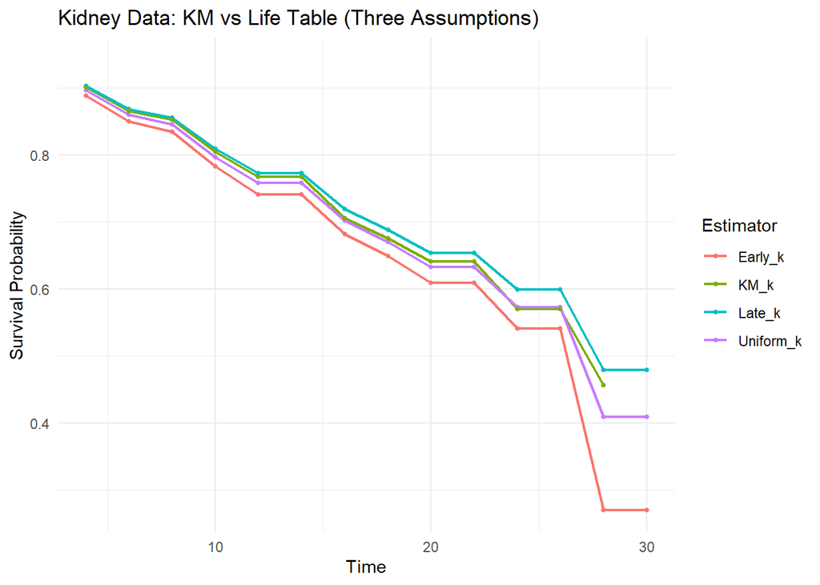

```r
km_fit_kidney <- survfit(Surv(time, delta) ~ 1, data = kidney)

km_summary_k <- summary(km_fit_kidney, times = breaks_k[-1])
km_df_k <- data.frame(time = km_summary_k$time, KM_survival_k = km_summary_k$surv)

act_df_k1 <- data.frame(
time = lt_k$time,
S_uniform = lt_k$S_uniform_k,
S_early   = lt_k$S_early_k,
S_late    = lt_k$S_late_k
)

compare_all_k <- left_join(act_df_k1, km_df_k, by = "time") %>%
rename(
Uniform_k = S_uniform,
Early_k  = S_early,
Late_k    = S_late,
KM_k      = KM_survival_k
)

compare_all_long_k <- compare_all_k %>%
pivot_longer(cols = c(Uniform_k, Early_k, Late_k, KM_k),
names_to = "Estimator",
values_to = "Survival")

ggplot(compare_all_long_k, aes(x = time, y = Survival, color = Estimator)) +
geom_line(size = 0.8) +
geom_point(size = 1) +
theme_minimal() +
labs(
title = "Kidney Data: KM vs Life Table (Three Assumptions)",
x = "Time",
y = "Survival Probability"
)
```

**Findings:** Overall pattern: All four estimators (KM and the three life-table versions) show a gradual decline in survival probability over time, as expected for the kidney dataset.

KM estimate (green): Serves as the benchmark. The life-table estimates stay close to this curve but differ depending on withdrawal assumptions.

Uniform-withdrawal assumption (purple): Lies between early and late, closely tracking the KM curve.It reflects the common assumption that censoring occurs uniformly within each interval. As the number at risk decreases, assumptions on withdrawals have a larger effect, causing wider separation between the curves.

**Interpretation:** The KM estimator remains stable, while life-table estimates vary slightly depending on censoring assumptions; early withdrawal underestimates survival most, late withdrawal overestimates, and uniform withdrawal approximates KM closely.

### 2.4 KM Curves by Catheter Type

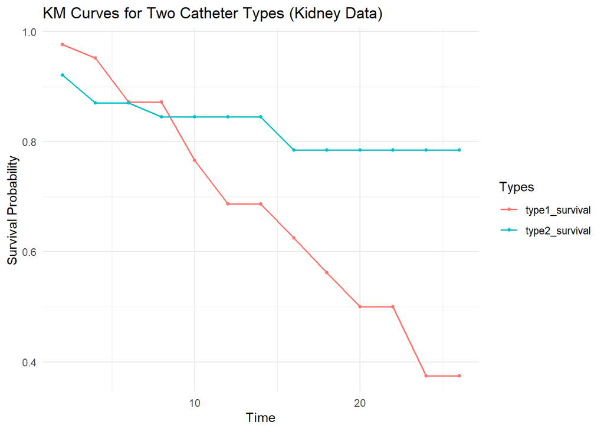

```r
fit1 <- survfit(Surv(time, delta) ~ 1, data = kidney[kidney$type==1,])
fit2 <- survfit(Surv(time, delta) ~ 1, data = kidney[kidney$type==2,])

fit1_summary <- summary(fit1, times = breaks_k[-1])
fit2_summary <- summary(fit2, times = breaks_k[-1])

fit1_df <- data.frame(time = fit1_summary$time, type1_survival = fit1_summary$surv)
fit2_df <- data.frame(time = fit2_summary$time, type2_survival = fit2_summary$surv)

com_df <- left_join(fit1_df, fit2_df, by = "time")

com_df_long <- com_df %>%
pivot_longer(cols = c(type1_survival, type2_survival),
names_to = "Types",
values_to = "Survival")

ggplot(com_df_long, aes(x = time, y = Survival, color = Types)) +
geom_line(size = 0.7) +
geom_point(size = 1) +
theme_minimal() +
labs(
title = "KM Curves for Two Catheter Types (Kidney Data)",
x = "Time",
y = "Survival Probability"
)
```

**Interpretation:** Overall, the KM plot suggests that *Type 2 catheters have better survival performance than Type 1 catheters*.

## Conclusion

Overall, the results suggest that in real datasets—especially those with moderate or smaller sample sizes like the kidney data—the choice of withdrawal assumption can introduce slight variations in survival estimates, particularly toward the tail of the distribution.

The comparative analysis using exact censoring times further demonstrates that grouping survival data into intervals leads to assumption-dependent bias in life-table methods. In contrast, the Kaplan–Meier estimator, which utilizes exact event times and avoids grouping assumptions, provides a more reliable and robust benchmark for survival analysis when such detailed information is available.

**Additional Finding:**  
In the kidney dataset, Type 2 catheters showed better survival performance, indicating that they may be preferred for future use.

## References:

• [Bias in Classical Life Tables Under Censoring](https://www.researchgate.net/publication/396785857_Bias_in_Classical_Life_Tables_Under_Censoring_A_Comparative_Study_With_Kaplan-Meier_Estimation_and_Actuarial_Estimation_Using_Real_and_Simulated_Data)

• Book: [Analysis of Failure and Survival Data : Book by P. Smith and Peter J Smith](https://api.pageplace.de/preview/DT0400.9781482295702_A31978986/preview-9781482295702_A31978986.pdf)